# Ceteris-paribus Profiles for Instance Level Profiles

Code snippets for R

Przemysław Biecek

for DALEX 1.0

In this section, we use an `DALEX::predict_profile()` function for calculation of Ceteris-paribus profiles.

If you want learn more about Ceteris-paribus profiles read https://pbiecek.github.io/ema/ceterisParibus.html.

Note that there are also other R packages that offer similar functionality, like `condvis`, `pdp`, `ICEbox`, `ALEPlot` or `iml`.

# Prepare data

In this example we will use the titanic data. It has few variables that are easy to understand. The `titanic_imputed` dataset from `DALEX` package has imputed missing values. Find more about the data https://pbiecek.github.io/ema/dataSetsIntro.html#TitanicDataset

```r
library("DALEX")
head(titanic_imputed)
```

```
##   gender age class    embarked  fare sibsp parch survived
## 1   male  42   3rd Southampton  7.11     0     0        0
## 2   male  13   3rd Southampton 20.05     0     2        0
## 3   male  16   3rd Southampton 20.05     1     1        0
## 4 female  39   3rd Southampton 20.05     1     1        1
## 5 female  16   3rd Southampton  7.13     0     0        1
## 6   male  25   3rd Southampton  7.13     0     0        1
```

# Train a model

Here we use `ranger` library to train a classification random forest model.

```r
library("ranger")
titanic_rf <- ranger(survived ~ class + gender + age + sibsp +
         parch + fare + embarked, data = titanic_imputed,
         probability = TRUE,
         classification = TRUE)
titanic_rf
```

```
## Ranger result
##
## Call:
##  ranger(survived ~ class + gender + age + sibsp + parch + fare +      embarked, data = titanic_imputed, probability = TRUE, classification = TRUE)
##
## Type:                             Probability estimation
## Number of trees:                  500
## Sample size:                      2207
## Number of independent variables:  7
## Mtry:                             2
## Target node size:                 10
## Variable importance mode:         none
## Splitrule:                        gini
## OOB prediction error (Brier s.):  0.1417578
```

# Prepare an explainer

Different models have different structures. We use `DALEX::explain()` function to create an uniform interface for the model

```r
library("DALEX")
titanic_ex <- explain(titanic_rf,
                data  = titanic_imputed,
                y     = titanic_imputed$survived,
                label = "Regression Forest for Titanic")
```

```
## Preparation of a new explainer is initiated
##   -> model label       :  Regression Forest for Titanic
##   -> data              :  2207  rows  8  cols
##   -> target variable   :  2207  values
##   -> data              :  A column identical to the target variable `y` has been found in the `data`.  (  WARNING  )
##   -> data              :  It is highly recommended to pass `data` without the target variable column
##   -> model_info        :  package ranger , ver. 0.11.2 , task classification (  default  )
##   -> predict function  :  yhat.ranger  will be used (  default  )
##   -> predicted values  :  numerical, min =  0.01605066 , mean =  0.3217188 , max =  0.9903434
##   -> residual function :  difference between y and yhat (  default  )
##   -> residuals         :  numerical, min =  -0.7937978 , mean =  0.0004379683 , max =  0.8826515
##   A new explainer has been created!
```

# Prepare an instance

For instance level explanations we need an observation for which we can generate explanation.

Let’s create a data.frame with a single row that corresponds to 8 years old boy from 1st class.

```r
johny_d <- data.frame(
            class = factor("1st", levels = c("1st", "2nd", "3rd", "deck crew",
                        "engineering crew", "restaurant staff", "victualling crew")),
            gender = factor("male", levels = c("female", "male")),
            age = 8,
            sibsp = 0,
            parch = 0,
            fare = 72,
            embarked = factor("Southampton", levels = c("Belfast",
                        "Cherbourg","Queenstown","Southampton")))
```

The predicted survival for `johny_d` is

```r
predict(titanic_ex, johny_d)
```

```
## [1] 0.4656422
```

# Ceteris-paribus profile with `predict_profile()`

The `DALEX::predict_profile()` function calculates the conditional profiles for a selected model and the instance of interest.

The resulting object is a data frame with CP profiles. Applying the generic function `plot()` to the object results in a profiles plotted with `ggplot2`.

The `DALEX::predict_profile()` function expects three arguments

- the model explainer,
- the data frame with the instance of interest,
- vector with names of variables for which CP profiles shall be calculated (by default all, but this may be time consuming).

As a result, the function yields an object of the class `ceteris_paribus_explainer`. It is a data frame with model predictions.

```r
cp_johny <- predict_profile(titanic_ex,
                             johny_d)
cp_johny
```

```
## Top profiles    :
##                class gender age sibsp parch fare    embarked    _yhat_ _vname_
## 1                1st   male   8     0     0   72 Southampton 0.4656422   class
## 1.1              2nd   male   8     0     0   72 Southampton 0.4342554   class
## 1.2              3rd   male   8     0     0   72 Southampton 0.4605316   class
## 1.3        deck crew   male   8     0     0   72 Southampton 0.4538085   class
## 1.4 engineering crew   male   8     0     0   72 Southampton 0.4299276   class
## 1.5 restaurant staff   male   8     0     0   72 Southampton 0.4075113   class
##     _ids_                       _label_
## 1       1 Regression Forest for Titanic
## 1.1     1 Regression Forest for Titanic
## 1.2     1 Regression Forest for Titanic
## 1.3     1 Regression Forest for Titanic
## 1.4     1 Regression Forest for Titanic
## 1.5     1 Regression Forest for Titanic
##
##
## Top observations:
##   class gender age sibsp parch fare    embarked    _yhat_
## 1   1st   male   8     0     0   72 Southampton 0.4656422
##                         _label_ _ids_
## 1 Regression Forest for Titanic     1
```

To plot CP profiles, we can use the generic `plot()` function. The optional argument `variables` selects variables that are to be plotted.

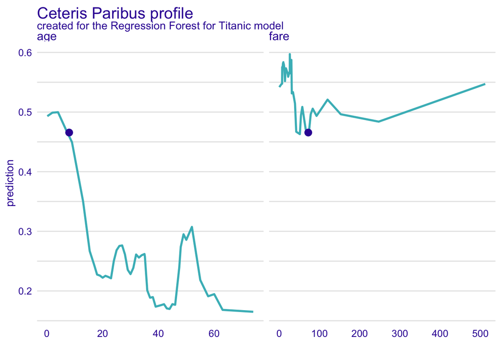

```r
plot(cp_johny, variables = c("age", "fare"))
```

It is the `ggplot2` object, so one can modify it as any other `ggplot2` object.

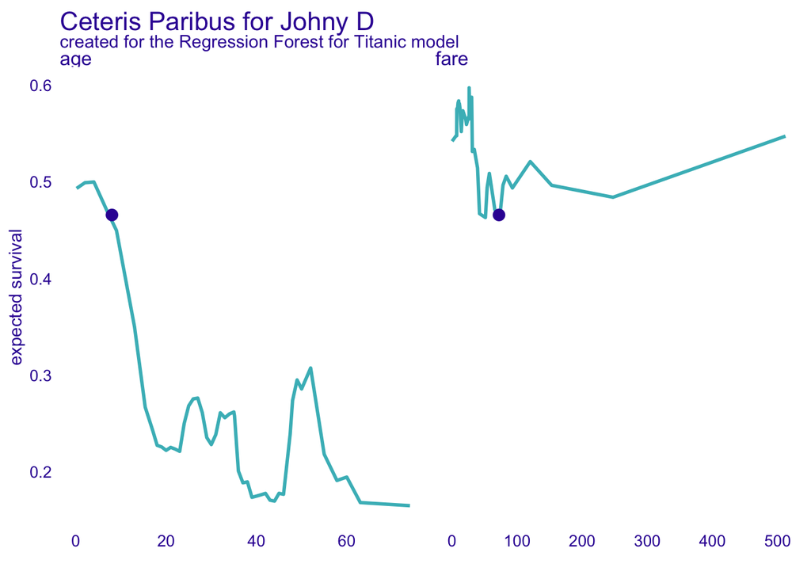

```r
library("ggplot2")
plot(cp_johny, variables = c("age", "fare")) +
  ggtitle("Ceteris Paribus for Johny D") +
  theme(panel.grid = element_blank()) +
  ylab("expected survival")
```

By default, all numerical variables are plotted. To plot CP profiles for categorical variables, we need to list them in the `variables` argument.

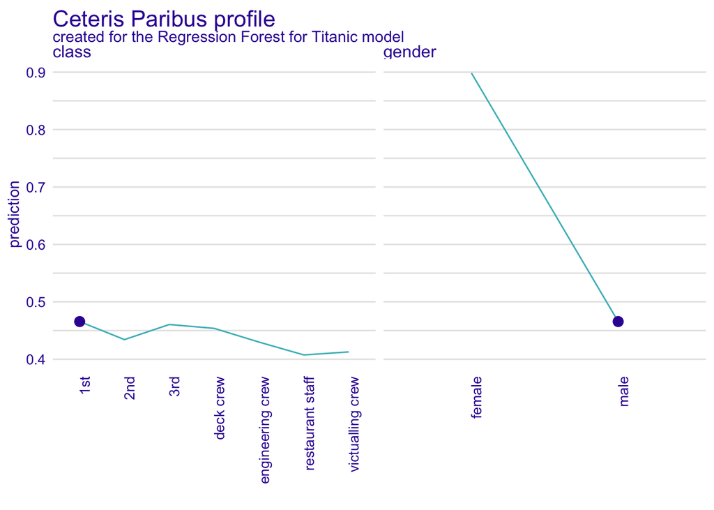

```r
plot(cp_johny, variables = c("class", "gender"))
```

# Advanced use of the `predict_profile()`

The `predict_profile()` is a very flexible function. To better understand how it can be used, we briefly review its arguments.

- `x`, `data`, `predict_function`, `label` - information about a model. If `x` is created with the `DALEX::explain` function, then other arguments are extracted from `x`,
- `new_observation` - instance (one or more), for which we want to calculate CP profiles. It should be a data frame with same variables as in the validation data.
- `variables` - names of explanatory variables, for which CP profiles are to be calculated. By default, the profiles will be constructed for all variables, which may be time consuming.
- `variable_splits` - a list of values for which CP profiles are to be calculated. By default, these are all values for categorical variables. For continuous variables, uniformly-placed values are selected; one can specify the number of the values with the `grid_points` argument (the default is 101).

The argument `variable_splits` specifies the variables (`age` and `fare`) for which CP profiles are to be calculated, together with the list of values at which the profiles are to be evaluated.

```r
variable_splits = list(age = seq(0, 70, 0.1),
                       fare = seq(0, 100, 0.1))

titanic_cp <- predict_profile(titanic_ex, johny_d,
                  variable_splits = variable_splits)
```

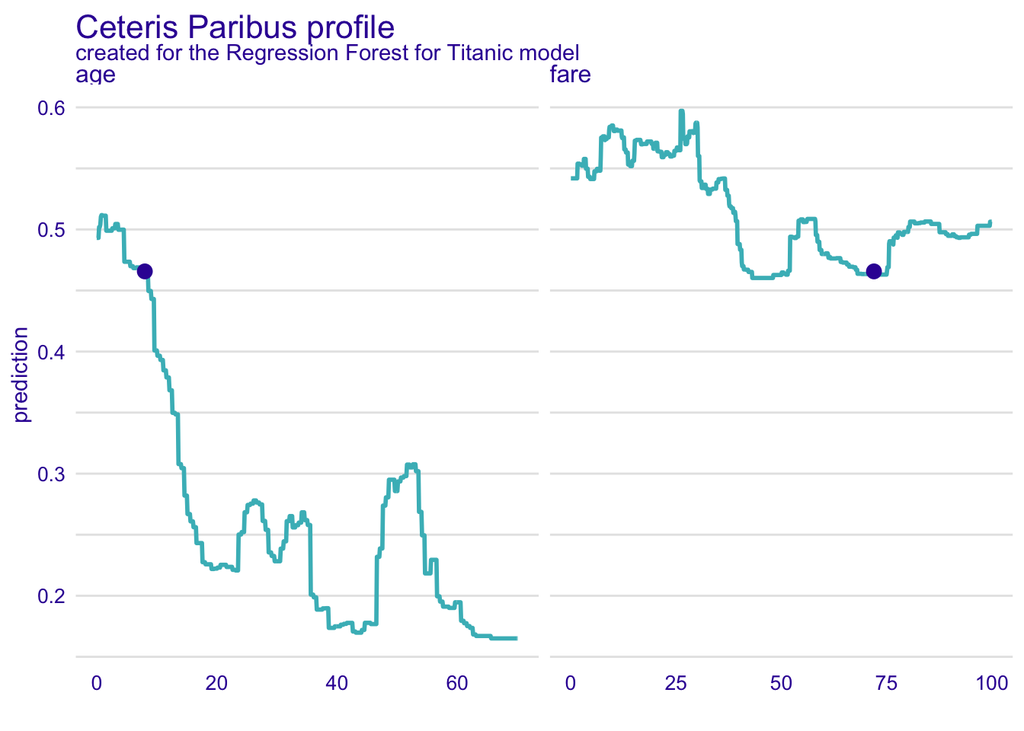

```r
plot(titanic_cp, variables = c("age", "fare"))
```

In the example below, we present the code to create CP profiles for two passengers, `henry` and `johny_d`. We use the `scale_color_manual` function to add names of passengers to the plot, and to control colors and positions.

[figure not shown]

```r
henry <- data.frame(
         class = factor("2nd", levels = c("1st", "2nd", "3rd", "deck crew",
                     "engineering crew", "restaurant staff", "victualling crew")),
         gender = factor("male", levels = c("female", "male")),
         age = 15,
         sibsp = 0,
         parch = 0,
         fare = 100,
         embarked = factor("Cherbourg", levels = c("Belfast",
                           "Cherbourg","Queenstown","Southampton")))

cp_henry <- predict_profile(titanic_ex, rbind(johny_d, henry))

plot(cp_henry, color = "_ids_") +
  scale_color_manual(name = "Passenger:", breaks = 1:2,
            values = c("#4378bf", "#8bdcbe"),
            labels = c("henry" , "johny_d"))
```

# Champion-challenger analysis with `predict_profile()`

One of the most interesting uses of the explainers is comparison of CP profiles for two or more of models.

```r
library("rms")
titanic_lmr <- lrm(survived ~ gender + rcs(age) + class +
         sibsp + parch + fare + embarked, titanic_imputed)
titanic_ex_lmr <- explain(titanic_lmr,
                        titanic_imputed,
                        label = "Logistic regression with splines",
                        verbose = FALSE)
```

```r
titanic_cp_lmr <- predict_profile(titanic_ex_lmr, johny_d,
                         variable_splits = variable_splits)
```

Subsequently, we construct the plot for both models.

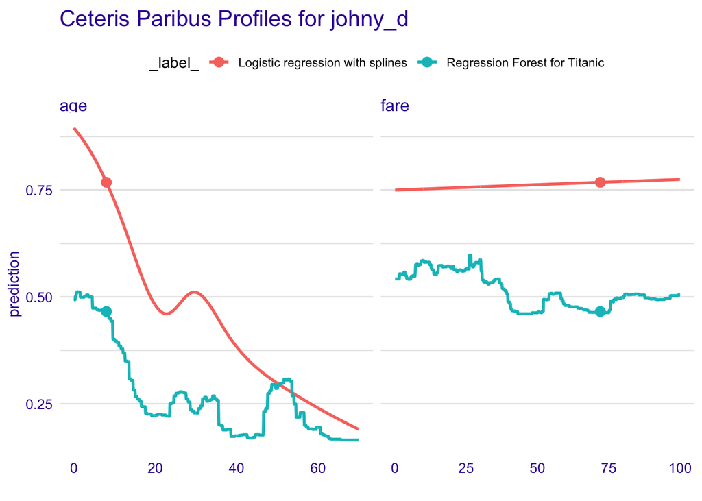

```r
plot(titanic_cp_lmr, titanic_cp, color = "_label_",
     variables = c("age", "fare")) +
     ggtitle("Ceteris Paribus Profiles for johny_d","")
```